# IODS course project

Anssi Mykkänen

# Introduction to Open Data Science - Course Project

# About the project

```r
date()
```

```
## [1] "Tue Dec 12 09:30:45 2023"
```

I found about the course from my PhD programme’s mailing list. I hope that I learn more about using R and GitHub. At least setting up the GitHub and RStudio was easy. I have some previous experience with R, but I don’t use it regularly.

Exercise set was nice warmup, but nothing too special. I wasn’t familiar with pipes operator (%>%) which seems like an useful option for writing R code. Tibbles were also a new thing for me. I had only used dataframes before, so its nice to learn that there is a better option.

GitHub link: https://github.com/njehh/IODS-project

# Assignment 2 data analysis

```r
date()
```

```
## [1] "Tue Dec 12 09:30:45 2023"
```

Here we go again…

1. **Let’s start by reading the data into R**

```r
library(readr)
library(tidyverse)
learning2023 <- read_csv("https://raw.githubusercontent.com/njehh/IODS-project/master/Data/learning2023.csv")
str(learning2023)
```

```
## spc_tbl_ [166 × 7] (S3: spec_tbl_df/tbl_df/tbl/data.frame)
##  $ gender  : chr [1:166] "F" "M" "F" "M" ...
##  $ age     : num [1:166] 53 55 49 53 49 38 50 37 37 42 ...
##  $ attitude: num [1:166] 3.7 3.1 2.5 3.5 3.7 3.8 3.5 2.9 3.8 2.1 ...
##  $ deep    : num [1:166] 3.58 2.92 3.5 3.5 3.67 ...
##  $ stra    : num [1:166] 3.38 2.75 3.62 3.12 3.62 ...
##  $ surf    : num [1:166] 2.58 3.17 2.25 2.25 2.83 ...
##  $ points  : num [1:166] 25 12 24 10 22 21 21 31 24 26 ...
##  - attr(*, "spec")=
##   .. cols(
##   ..   gender = col_character(),
##   ..   age = col_double(),
##   ..   attitude = col_double(),
##   ..   deep = col_double(),
##   ..   stra = col_double(),
##   ..   surf = col_double(),
##   ..   points = col_double()
##   .. )
##  - attr(*, "problems")=<externalptr>
```

The data are from a survey related to learning statistics from a statistics course organized in 2014. It includes data from 166 participants (rows). Columns have responder demographic information (age and gender), exam points (points), and attitude towards learning statistics. The central measure is learning method measured by three dimensions (deep, surface and strategic).

2. **Exploring the data**

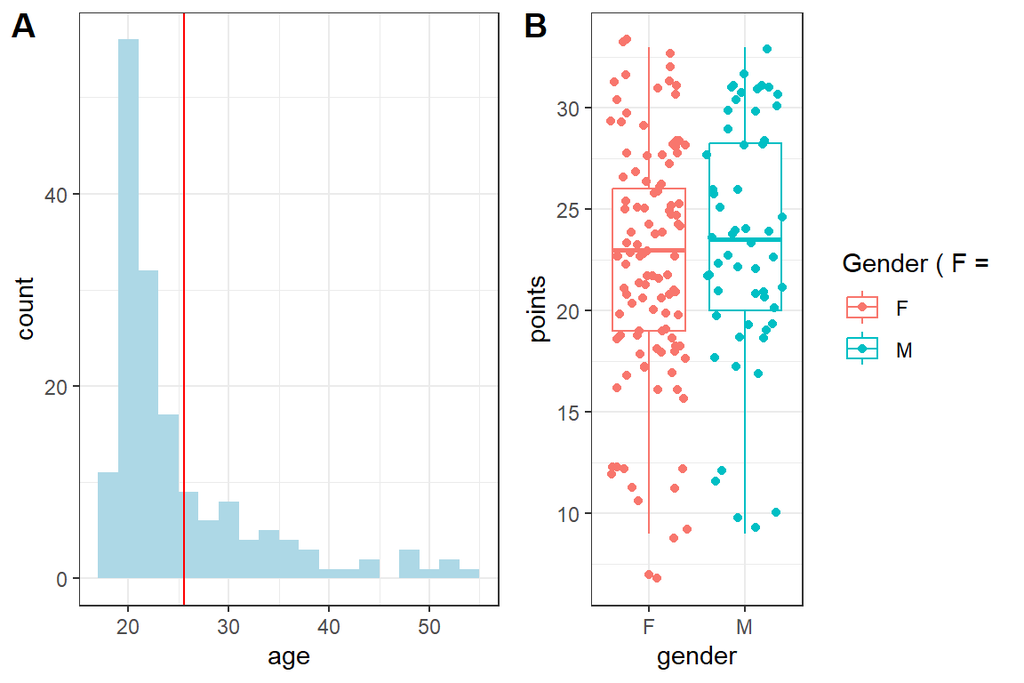

```r
library(ggplot2)
library(ggpubr)
theme_set(theme_bw())

ages <- learning2023 %>%
    ggplot(aes(x = age)) +
    geom_histogram(binwidth = 2, fill = "lightblue") +
    geom_vline(xintercept=mean(learning2023$age), color = "red")


gen <- learning2023 %>%
    ggplot(aes(x = gender, y = points, colour = gender)) +
    geom_boxplot()+
    geom_jitter() +
    labs(colour = "Gender ( F = ")

ggarrange(ages, gen,
    labels = c("A", "B"),
    ncol = 2, nrow = 1)
```

**Figure A** shows age distribution of the participants, the red line indicates the mean. **B** shows the distribution of exam points by gender.

Most of the participants are between 20 to 30 years old. There is no clear difference in the test scores by gender.

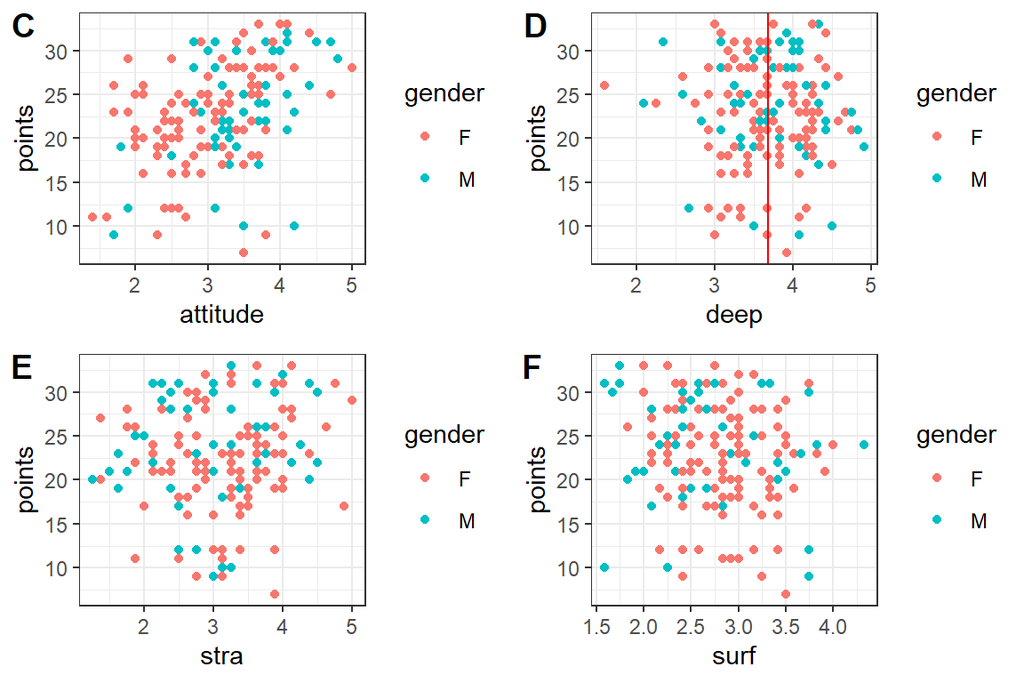

```r
att <- learning2023 %>%
  ggplot(aes(y = points, x = attitude, colour = gender)) +
  geom_point()

dee <- learning2023 %>%
  ggplot(aes(y = points, x = deep, colour = gender)) +
  geom_point()+
  geom_vline(xintercept=mean(learning2023$deep), color = "red")

sta <- learning2023 %>%
  ggplot(aes(y = points, x = stra, colour = gender)) +
  geom_point()

sur <- learning2023 %>%
  ggplot(aes(y = points, x = surf, colour = gender)) +
  geom_point()

ggarrange(att, dee, sta, sur,
    labels = c("C", "D", "E", "F"),
    ncol = 2, nrow = 2)
```

*Exam points plotted againts attitude towards statistics **(C)**, and approach to learning : deep **(D)**, strategic **(E)** , and surface **(F)** approach.*

Attitude towards statistics seems to correlate quite well with the exam points. The mean of deep approach is quite high (red vertical line in the plot), and distribution is towards the high end of the scale. No clear correlation between strategic approach and the exam points can be seen. Based on the visualization, it seems that there may be negative correlation between surface approach and exam points.

```r
learning2023 %>%
  group_by(gender) %>%
  summarise(mean(age), mean(points),mean(attitude), mean(deep), mean(stra), mean(surf))
```

```
## # A tibble: 2 × 7
##   gender `mean(age)` `mean(points)` `mean(attitude)` `mean(deep)` `mean(stra)`
##   <chr>        <dbl>          <dbl>            <dbl>        <dbl>        <dbl>
## 1 F             24.9           22.3             2.99         3.66         3.20
## 2 M             26.8           23.5             3.44         3.72         2.96
## # ℹ 1 more variable: `mean(surf)` <dbl>
```

**3. and 4. Linear regression**

```r
model1 <- learning2023 %>%
  lm(points ~ gender+age+attitude, data =.)

summary(model1)
```

```
##
## Call:
## lm(formula = points ~ gender + age + attitude, data = .)
##
## Residuals:
##      Min       1Q   Median       3Q      Max
## -17.4590  -3.3221   0.2186   4.0247  10.4632
##
## Coefficients:
##             Estimate Std. Error t value Pr(>|t|)
## (Intercept) 13.42910    2.29043   5.863 2.48e-08 ***
## genderM     -0.33054    0.91934  -0.360    0.720
## age         -0.07586    0.05367  -1.414    0.159
## attitude     3.60657    0.59322   6.080 8.34e-09 ***
## ---
## Signif. codes:  0 '***' 0.001 '**' 0.01 '*' 0.05 '.' 0.1 ' ' 1
##
## Residual standard error: 5.315 on 162 degrees of freedom
## Multiple R-squared:  0.2018, Adjusted R-squared:  0.187
## F-statistic: 13.65 on 3 and 162 DF,  p-value: 5.536e-08
```

The P-value of the model is 5.5x10<sup>-8</sup>. Based on the multiple R-squared value, the model explains 20% of the variation in the exam scores. There is statistically significant correlation between attitude and exam points (*P*=8.3x10<sup>-9</sup>). It seems that better attitude towards statistics yields higher points in the exam. Gender or age were not statistically significant predictors of exam points, thus we remove them from the model.

```r
model2 <- learning2023 %>%
  lm(points ~ attitude, data =.)

summary(model2)
```

```
##
## Call:
## lm(formula = points ~ attitude, data = .)
##
## Residuals:
##      Min       1Q   Median       3Q      Max
## -16.9763  -3.2119   0.4339   4.1534  10.6645
##
## Coefficients:
##             Estimate Std. Error t value Pr(>|t|)
## (Intercept)  11.6372     1.8303   6.358 1.95e-09 ***
## attitude      3.5255     0.5674   6.214 4.12e-09 ***
## ---
## Signif. codes:  0 '***' 0.001 '**' 0.01 '*' 0.05 '.' 0.1 ' ' 1
##
## Residual standard error: 5.32 on 164 degrees of freedom
## Multiple R-squared:  0.1906, Adjusted R-squared:  0.1856
## F-statistic: 38.61 on 1 and 164 DF,  p-value: 4.119e-09
```

When age and gender were removed from the model, attitude remained as significant variable. The P-value of the model is now a little bit smaller (*P*=4.1<sup>-9</sup>). Based on this model, attitude correlates with exam results. The estimate trend is positive, which means that attitude has positive correlation with exam points. Multiple R-squared of the model is 0.19, which means that attitude explains 19% of the variation in exam scores in this dataset.

**5. Plotting the linear regression**

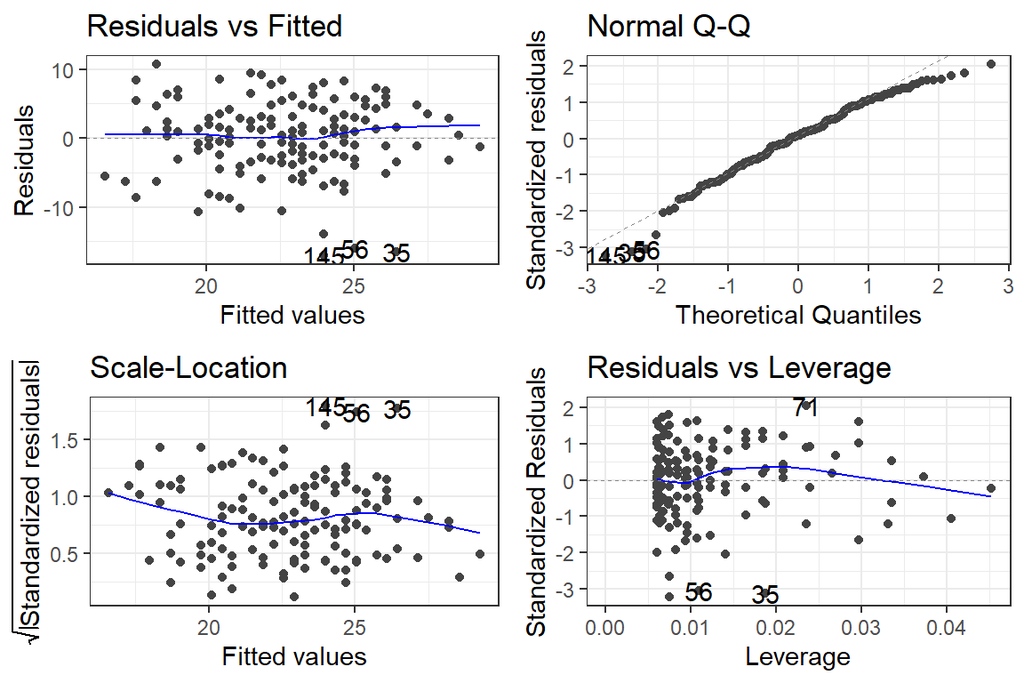

```r
library("ggfortify")
autoplot(model2)
```

Residuals vs fitted values plot tells whether the residuals vary depending on the fitted value. Based on the plot it seems that fitted values don’t affect the residuals. Mean (blue line) seems to be a horizontal line.

In the QQ-plot there are few outliers in the extreme ends. However, in the middle part it seems to correlate quite well.

In the residuals vs leverage plot, observations seem to be within the Cook’s distance.

In conclusion, based on the model it seems that motivation towards statistics has positive correlation with exam points. The residual plots and normal QQ-plot seem to be ok. There are few outlier, which can be seen especially in the QQ-plot but otherwise it looks okay. At least it seems that there is not any systematic problem with the data. There are few outlier in the dataset, but it does not have big impact on the results.

# Assignment 3 data analysis

```r
date()
```

```
## [1] "Tue Dec 12 09:30:49 2023"
```

```r
library(tidyverse)
library(ggplot2)
library(finalfit)
library(broom)
library(boot)
theme_set(theme_bw())
```

**2. reading the data**

```r
student_data <- read_csv("https://raw.githubusercontent.com/KimmoVehkalahti/Helsinki-Open-Data-Science/master/datasets/alc.csv")
glimpse(student_data)
```

```
## Rows: 370
## Columns: 35
## $ school     <chr> "GP", "GP", "GP", "GP", "GP", "GP", "GP", "GP", "GP", "GP",…
## $ sex        <chr> "F", "F", "F", "F", "F", "M", "M", "F", "M", "M", "F", "F",…
## $ age        <dbl> 18, 17, 15, 15, 16, 16, 16, 17, 15, 15, 15, 15, 15, 15, 15,…
## $ address    <chr> "U", "U", "U", "U", "U", "U", "U", "U", "U", "U", "U", "U",…
## $ famsize    <chr> "GT3", "GT3", "LE3", "GT3", "GT3", "LE3", "LE3", "GT3", "LE…
## $ Pstatus    <chr> "A", "T", "T", "T", "T", "T", "T", "A", "A", "T", "T", "T",…
## $ Medu       <dbl> 4, 1, 1, 4, 3, 4, 2, 4, 3, 3, 4, 2, 4, 4, 2, 4, 4, 3, 3, 4,…
## $ Fedu       <dbl> 4, 1, 1, 2, 3, 3, 2, 4, 2, 4, 4, 1, 4, 3, 2, 4, 4, 3, 2, 3,…
## $ Mjob       <chr> "at_home", "at_home", "at_home", "health", "other", "servic…
## $ Fjob       <chr> "teacher", "other", "other", "services", "other", "other", …
## $ reason     <chr> "course", "course", "other", "home", "home", "reputation", …
## $ guardian   <chr> "mother", "father", "mother", "mother", "father", "mother",…
## $ traveltime <dbl> 2, 1, 1, 1, 1, 1, 1, 2, 1, 1, 1, 3, 1, 2, 1, 1, 1, 3, 1, 1,…
```

[output cut: 22 more lines]

The dataset includes data from two Portuguese schools. It includes data for 370 students (rows) and 35 different attributes (columns). It has data for two student demographics such as sex, age and home address type (urban or rural). For student performance it includes data from Math and Portuguese classes from three grades.

##Exploring student alcohol consumption

**3. setting the study hypothesis**

I decided to study how sex, address, paid, and absences may affect alcohol use. My hypothesis is that males use more alcohol than females. *address* variable tells if the student’s home address is rural (R) or urban (U), and I think that there may be differences between urban and rural locations. *paid* variable tell if student paid for extra classes in either of the subjects (math or portugal). My hypothesis is that those who paid for extra classes drink less alcohol. *absences* is the number of student’s school absences. My hypothesis is that those who drink more alcohol have more absences.

```r
#creating dataset with only the selected variables
model_data <- student_data %>%
  select(sex, address, paid, absences, alc_use, high_use)

glimpse(model_data)
```

```
## Rows: 370
## Columns: 6
## $ sex      <chr> "F", "F", "F", "F", "F", "M", "M", "F", "M", "M", "F", "F", "…
## $ address  <chr> "U", "U", "U", "U", "U", "U", "U", "U", "U", "U", "U", "U", "…
## $ paid     <chr> "no", "no", "yes", "yes", "yes", "yes", "no", "no", "yes", "y…
## $ absences <dbl> 5, 3, 8, 1, 2, 8, 0, 4, 0, 0, 1, 2, 1, 1, 0, 5, 8, 3, 9, 5, 0…
## $ alc_use  <dbl> 1.0, 1.0, 2.5, 1.0, 1.5, 1.5, 1.0, 1.0, 1.0, 1.0, 1.5, 1.0, 2…
## $ high_use <lgl> FALSE, FALSE, TRUE, FALSE, FALSE, FALSE, FALSE, FALSE, FALSE,…
```

**4. Exploration of the data**

*Graphical exploration*

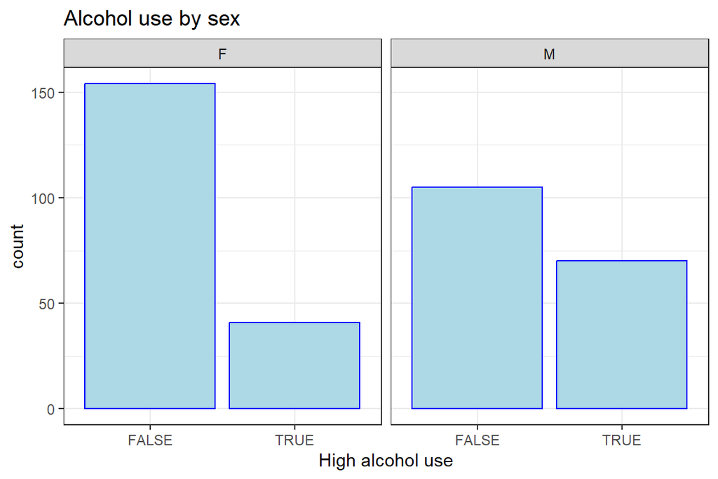

```r
model_data %>%
  ggplot(aes(x = high_use))+
  geom_bar(colour = "blue", fill="lightblue")+
  facet_wrap(~sex)+
  labs(x="High alcohol use", title = "Alcohol use by sex")
```

Based on the visual inspection, it seems that high alcohol use is more common among men.

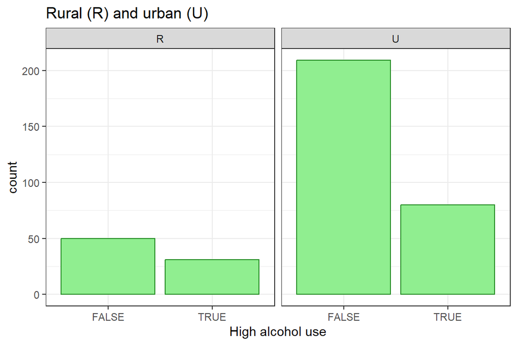

```r
model_data %>%
  ggplot(aes(x = high_use))+
  geom_bar(colour = "forestgreen", fill="lightgreen")+
  facet_wrap(~address)+
  labs(x="High alcohol use", title="Rural (R) and urban (U)")
```

It seems that high alcohol use is proportionally more common in rural areas than in urban areas.

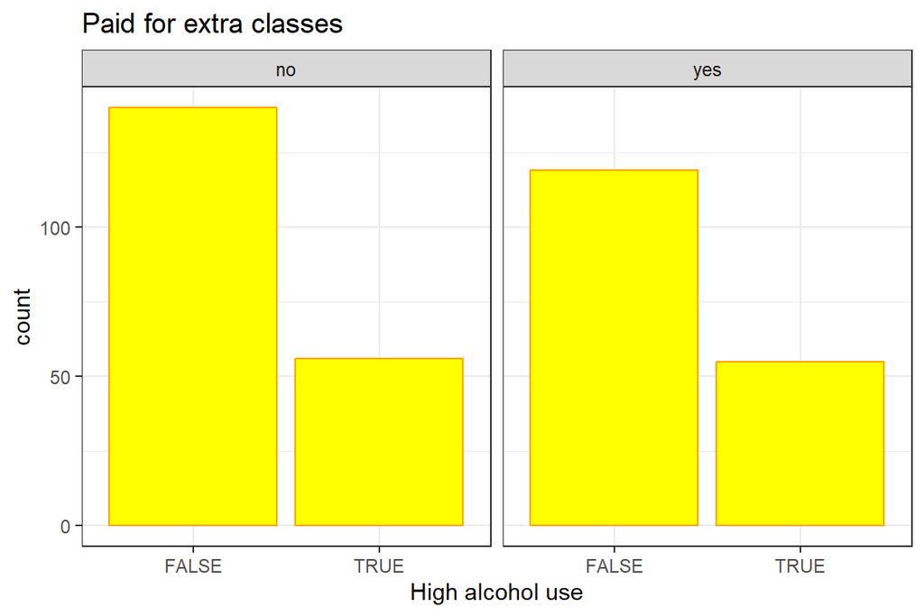

```r
model_data %>%
  ggplot(aes(x = high_use))+
  geom_bar(colour = "orange", fill="yellow")+
  facet_wrap(~paid)+
  labs(x="High alcohol use", title = "Paid for extra classes")
```

No clear difference is seen between those who paid for extra classes and those did not. There seems to be weak tendency towards high alcohol use in those who paid for extra classes.

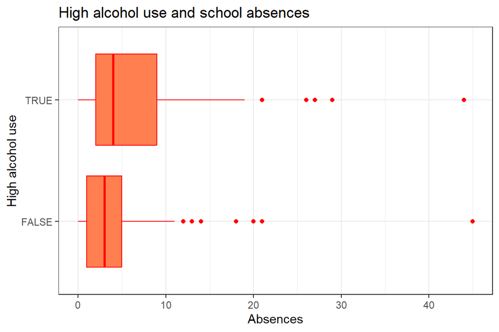

```r
model_data %>%
  ggplot(aes(y = high_use, x=absences))+
  geom_boxplot(colour = "red", fill="coral")+
  labs(y="High alcohol use", x = "Absences", title = "High alcohol use and school absences")
```

It seems that high alcohol use correlates with school absences.

*Numerical exploration*

```r
model_data %>%
  summary_factorlist("high_use", c("sex", "address", "paid", "absences"),
                     cont = "mean", p = T, add_dependent_label = TRUE)
```

```
##  Dependent: high_use                FALSE      TRUE      p
##                  sex         F 154 (59.5) 41 (36.9) <0.001
##                              M 105 (40.5) 70 (63.1)
##              address         R  50 (19.3) 31 (27.9)  0.089
##                              U 209 (80.7) 80 (72.1)
##                 paid        no 140 (54.1) 56 (50.5)  0.601
##                            yes 119 (45.9) 55 (49.5)
##             absences Mean (SD)  3.7 (4.5) 6.4 (7.1) <0.001
```

As was seen in the graphical exploration, males have statistically higher portion of high use of alcohol. It seems that the hypothesis was correct on this part.

There is no statistical significance in high alcohol between urban and rural locations. However, it seems that there is tendency towards higher alcohol use in rural areas. Hypothesis may or may not be correct.

There is no difference in alcohol between those who paid or did no pay for extra classes.

Absences correlate with high use of alcohol as per hypothesis. The difference is statistically significant.

**5. logistic regression**

```r
fit1 <- glm(high_use~sex+address+paid+absences, family = binomial, data =model_data)

summary(fit1)
```

```
##
## Call:
## glm(formula = high_use ~ sex + address + paid + absences, family = binomial,
##     data = model_data)
##
## Coefficients:
##             Estimate Std. Error z value Pr(>|z|)
## (Intercept) -1.68698    0.33536  -5.030 4.89e-07 ***
## sexM         1.08339    0.24879   4.355 1.33e-05 ***
## addressU    -0.48422    0.27938  -1.733   0.0831 .
## paidyes      0.36195    0.24452   1.480   0.1388
## absences     0.09809    0.02349   4.177 2.96e-05 ***
## ---
## Signif. codes:  0 '***' 0.001 '**' 0.01 '*' 0.05 '.' 0.1 ' ' 1
##
## (Dispersion parameter for binomial family taken to be 1)
##
##     Null deviance: 452.04  on 369  degrees of freedom
## Residual deviance: 410.71  on 365  degrees of freedom
## AIC: 420.71
##
## Number of Fisher Scoring iterations: 4
```

```r
fit1 %>%
  tidy(conf.int=T, exp=T) #calculate confidence intervals and transfrom back from the natural logarithm with exp()
```

```
## # A tibble: 5 × 7
##   term        estimate std.error statistic     p.value conf.low conf.high
##   <chr>          <dbl>     <dbl>     <dbl>       <dbl>    <dbl>     <dbl>
## 1 (Intercept)    0.185    0.335      -5.03 0.000000489   0.0939     0.351
## 2 sexM           2.95     0.249       4.35 0.0000133     1.83       4.85
## 3 addressU       0.616    0.279      -1.73 0.0831        0.357      1.07
## 4 paidyes        1.44     0.245       1.48 0.139         0.891      2.33
## 5 absences       1.10     0.0235      4.18 0.0000296     1.06       1.16
```

In the table above, estimate column tells the odd ratios, while conf.low is the lower limit and conf.high the upper limit of 95% confidence interval.

In the logistic regression model sex and absences had statistically significant association.

Hypothesis regarding sex was that high use of alcohol is more common among males. The logistic regression model supports this hypothesis and the odd ratio for high alcohol use is 2.95.

Another hypothesis was that there is difference between rural and urban areas. The difference is not statistically significant, but the p-value is quite small (0.08), and there seems to be at least trend that alcohol use is less common in urban areas (odd ratio: 0.62, 95% confidence interval: 0.36-1.07).

Hypothesis for association between paid classes and alcohol use does not seem to be correct. There was no difference according to this analysis.

**6.**

```r
fit2 <- glm(high_use~sex+absences, family = binomial, data =model_data) #new model with only statistically significant variables

summary(fit2)
```

```
##
## Call:
## glm(formula = high_use ~ sex + absences, family = binomial, data = model_data)
##
## Coefficients:
##             Estimate Std. Error z value Pr(>|z|)
## (Intercept) -1.85303    0.22609  -8.196 2.49e-16 ***
## sexM         1.03451    0.24395   4.241 2.23e-05 ***
## absences     0.09671    0.02336   4.140 3.48e-05 ***
## ---
## Signif. codes:  0 '***' 0.001 '**' 0.01 '*' 0.05 '.' 0.1 ' ' 1
##
## (Dispersion parameter for binomial family taken to be 1)
##
##     Null deviance: 452.04  on 369  degrees of freedom
## Residual deviance: 415.66  on 367  degrees of freedom
## AIC: 421.66
##
## Number of Fisher Scoring iterations: 4
```

```r
probabilities <- predict.glm(fit2, type = "response") #predict probabilites based on the glm-model

model_data <- model_data %>%
    mutate(probability = probabilities,
           prediction = probability>0.5) #create prediction variable, which is TRUE when probability > 0.5

prediction_table <- table(high_use = model_data$high_use, prediction = model_data$prediction)
prediction_table
```

```
##         prediction
## high_use FALSE TRUE
##    FALSE   251    8
##    TRUE     86   25
```

```r
training_error <- (prediction_table[1,2] + prediction_table[2,1])/370 #proportion of correctly classified values
training_error
```

```
## [1] 0.2540541
```

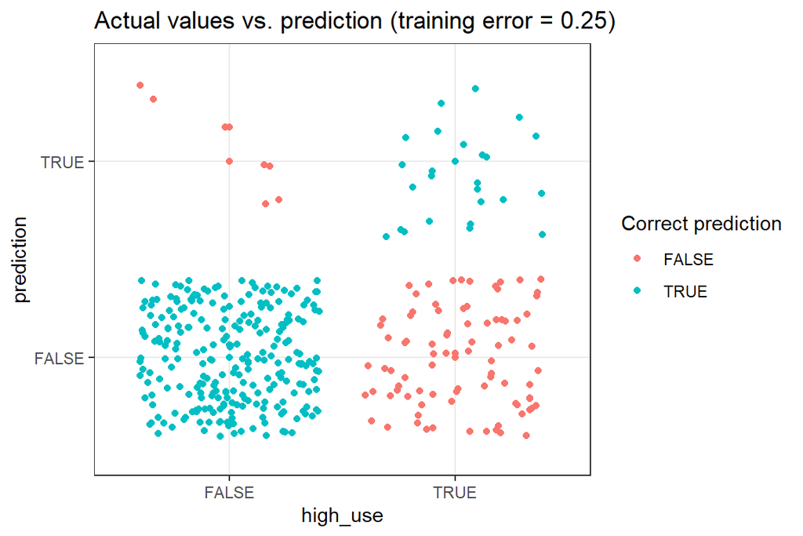

```r
v1 = c("word", "ok")

model_data %>%
  mutate(correct = high_use==prediction) %>%
  ggplot(aes(x = high_use, y=prediction, colour=correct))+
  geom_point()+
  geom_jitter()+
  labs(colour = "Correct prediction", title = "Actual values vs. prediction (training error = 0.25)")
```

Model has training error of 25%. It has tendency towards underprediction of alcohol use. It predicts around 3% of false positives (8/259), but large amount of false negatives, around 77% (86/111). I would not say that this model is actually useful.

```r
easy_prediction <- model_data %>%
  mutate(high_absences = absences>6) #lets compare how well over 6 absences predict high alcohol use

pred_table2 <- table(high_use = easy_prediction$high_use, prediction = easy_prediction$high_absences)

pred_table2
```

```
##         prediction
## high_use FALSE TRUE
##    FALSE   214   45
##    TRUE     71   40
```

If we take more simple approach and predict that those who have over 6 absences have high alcohol use we get more true positives and less true negative.

```r
(pred_table2[1,2] + pred_table2[2,1])/370
```

```
## [1] 0.3135135
```

Training error of the simpler model is 31% which is a little bit worse than the models training error (25%).

**7. cross-validation**

```r
loss_func <- function(class, prob) {
  n_wrong <- abs(class - prob) > 0.5
  mean(n_wrong)
}


# K-fold cross-validation
cv <- cv.glm(data = model_data, cost = loss_func, glmfit = fit2, K = nrow(model_data))

# average number of wrong predictions in the cross validation
cv$delta[1]
```

```
## [1] 0.2540541
```

# Assignment 3 data analysis

```r
date()
```

```
## [1] "Tue Dec 12 09:30:55 2023"
```

```r
library(tidyverse)
library(ggplot2)
library(finalfit)
library(broom)
library(boot)
theme_set(theme_bw())
```

**2. reading the data**

```r
student_data <- read_csv("https://raw.githubusercontent.com/KimmoVehkalahti/Helsinki-Open-Data-Science/master/datasets/alc.csv")
glimpse(student_data)
```

```
## Rows: 370
## Columns: 35
## $ school     <chr> "GP", "GP", "GP", "GP", "GP", "GP", "GP", "GP", "GP", "GP",…
## $ sex        <chr> "F", "F", "F", "F", "F", "M", "M", "F", "M", "M", "F", "F",…
## $ age        <dbl> 18, 17, 15, 15, 16, 16, 16, 17, 15, 15, 15, 15, 15, 15, 15,…
## $ address    <chr> "U", "U", "U", "U", "U", "U", "U", "U", "U", "U", "U", "U",…
## $ famsize    <chr> "GT3", "GT3", "LE3", "GT3", "GT3", "LE3", "LE3", "GT3", "LE…
## $ Pstatus    <chr> "A", "T", "T", "T", "T", "T", "T", "A", "A", "T", "T", "T",…
## $ Medu       <dbl> 4, 1, 1, 4, 3, 4, 2, 4, 3, 3, 4, 2, 4, 4, 2, 4, 4, 3, 3, 4,…
## $ Fedu       <dbl> 4, 1, 1, 2, 3, 3, 2, 4, 2, 4, 4, 1, 4, 3, 2, 4, 4, 3, 2, 3,…
## $ Mjob       <chr> "at_home", "at_home", "at_home", "health", "other", "servic…
## $ Fjob       <chr> "teacher", "other", "other", "services", "other", "other", …
## $ reason     <chr> "course", "course", "other", "home", "home", "reputation", …
## $ guardian   <chr> "mother", "father", "mother", "mother", "father", "mother",…
## $ traveltime <dbl> 2, 1, 1, 1, 1, 1, 1, 2, 1, 1, 1, 3, 1, 2, 1, 1, 1, 3, 1, 1,…
```

[output cut: 22 more lines]

The dataset includes data from two Portuguese schools. It includes data for 370 students (rows) and 35 different attributes (columns). It has data for two student demographics such as sex, age and home address type (urban or rural). For student performance it includes data from Math and Portuguese classes from three grades.

##Exploring student alcohol consumption

**3. setting the study hypothesis**

I decided to study how sex, address, paid, and absences may affect alcohol use. My hypothesis is that males use more alcohol than females. *address* variable tells if the student’s home address is rural (R) or urban (U), and I think that there may be differences between urban and rural locations. *paid* variable tell if student paid for extra classes in either of the subjects (math or portugal). My hypothesis is that those who paid for extra classes drink less alcohol. *absences* is the number of student’s school absences. My hypothesis is that those who drink more alcohol have more absences.

```r
#creating dataset with only the selected variables
model_data <- student_data %>%
  select(sex, address, paid, absences, alc_use, high_use)

glimpse(model_data)
```

```
## Rows: 370
## Columns: 6
## $ sex      <chr> "F", "F", "F", "F", "F", "M", "M", "F", "M", "M", "F", "F", "…
## $ address  <chr> "U", "U", "U", "U", "U", "U", "U", "U", "U", "U", "U", "U", "…
## $ paid     <chr> "no", "no", "yes", "yes", "yes", "yes", "no", "no", "yes", "y…
## $ absences <dbl> 5, 3, 8, 1, 2, 8, 0, 4, 0, 0, 1, 2, 1, 1, 0, 5, 8, 3, 9, 5, 0…
## $ alc_use  <dbl> 1.0, 1.0, 2.5, 1.0, 1.5, 1.5, 1.0, 1.0, 1.0, 1.0, 1.5, 1.0, 2…
## $ high_use <lgl> FALSE, FALSE, TRUE, FALSE, FALSE, FALSE, FALSE, FALSE, FALSE,…
```

**4. Exploration of the data**

*Graphical exploration*

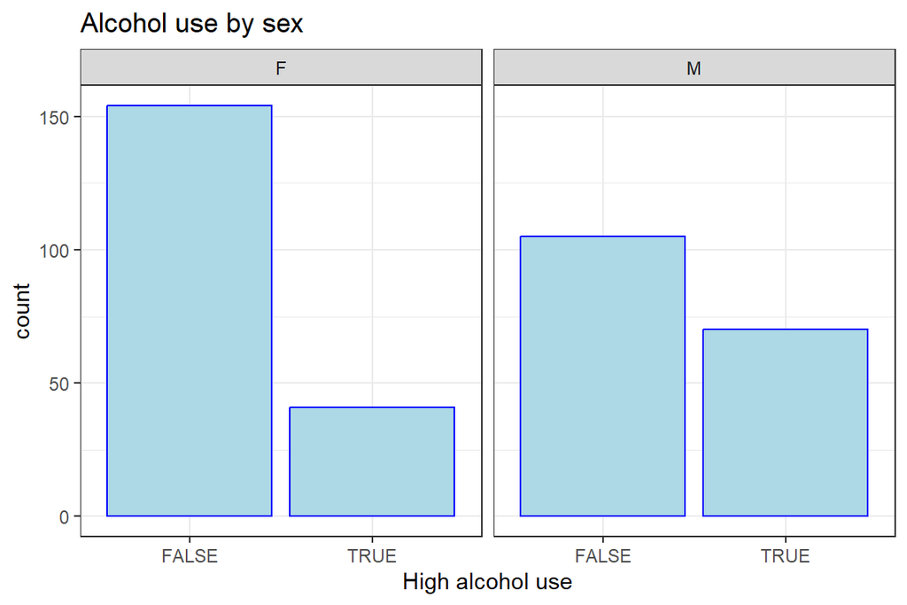

```r
model_data %>%
  ggplot(aes(x = high_use))+
  geom_bar(colour = "blue", fill="lightblue")+
  facet_wrap(~sex)+
  labs(x="High alcohol use", title = "Alcohol use by sex")
```

Based on the visual inspection, it seems that high alcohol use is more common among men.

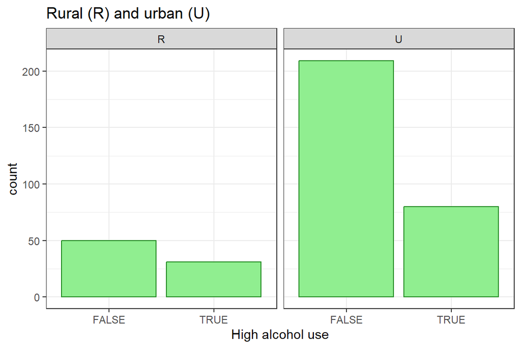

```r
model_data %>%
  ggplot(aes(x = high_use))+
  geom_bar(colour = "forestgreen", fill="lightgreen")+
  facet_wrap(~address)+
  labs(x="High alcohol use", title="Rural (R) and urban (U)")
```

It seems that high alcohol use is proportionally more common in rural areas than in urban areas.

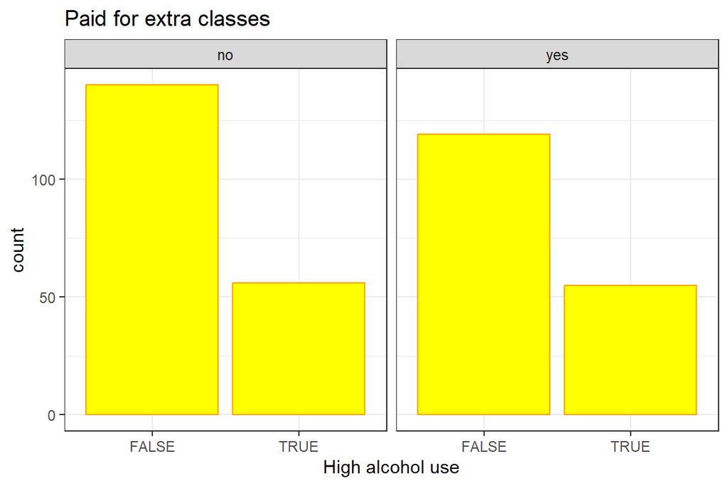

```r
model_data %>%
  ggplot(aes(x = high_use))+
  geom_bar(colour = "orange", fill="yellow")+
  facet_wrap(~paid)+
  labs(x="High alcohol use", title = "Paid for extra classes")
```

No clear difference is seen between those who paid for extra classes and those did not. There seems to be weak tendency towards high alcohol use in those who paid for extra classes.

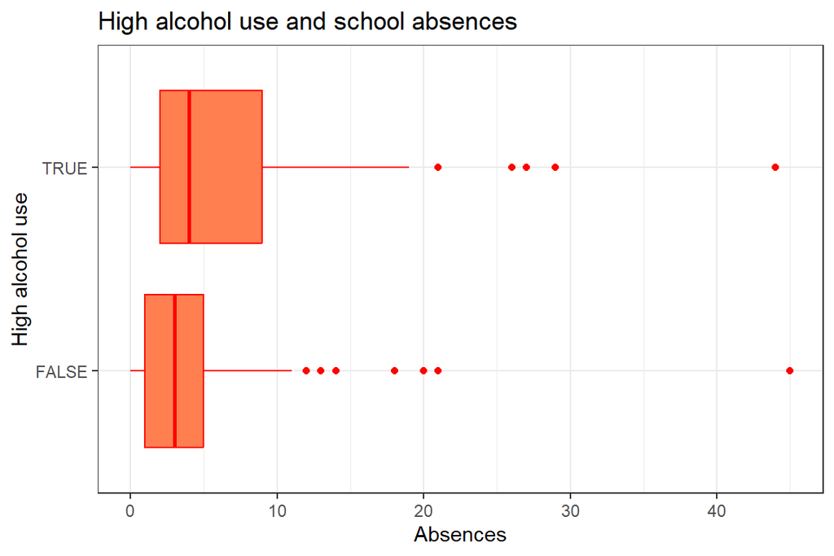

```r
model_data %>%
  ggplot(aes(y = high_use, x=absences))+
  geom_boxplot(colour = "red", fill="coral")+
  labs(y="High alcohol use", x = "Absences", title = "High alcohol use and school absences")
```

It seems that high alcohol use correlates with school absences.

*Numerical exploration*

```r
model_data %>%
  summary_factorlist("high_use", c("sex", "address", "paid", "absences"),
                     cont = "mean", p = T, add_dependent_label = TRUE)
```

```
##  Dependent: high_use                FALSE      TRUE      p
##                  sex         F 154 (59.5) 41 (36.9) <0.001
##                              M 105 (40.5) 70 (63.1)
##              address         R  50 (19.3) 31 (27.9)  0.089
##                              U 209 (80.7) 80 (72.1)
##                 paid        no 140 (54.1) 56 (50.5)  0.601
##                            yes 119 (45.9) 55 (49.5)
##             absences Mean (SD)  3.7 (4.5) 6.4 (7.1) <0.001
```

As was seen in the graphical exploration, males have statistically higher portion of high use of alcohol. It seems that the hypothesis was correct on this part.

There is no statistical significance in high alcohol between urban and rural locations. However, it seems that there is tendency towards higher alcohol use in rural areas. Hypothesis may or may not be correct.

There is no difference in alcohol between those who paid or did no pay for extra classes.

Absences correlate with high use of alcohol as per hypothesis. The difference is statistically significant.

**5. logistic regression**

```r
fit1 <- glm(high_use~sex+address+paid+absences, family = binomial, data =model_data)

summary(fit1)
```

```
##
## Call:
## glm(formula = high_use ~ sex + address + paid + absences, family = binomial,
##     data = model_data)
##
## Coefficients:
##             Estimate Std. Error z value Pr(>|z|)
## (Intercept) -1.68698    0.33536  -5.030 4.89e-07 ***
## sexM         1.08339    0.24879   4.355 1.33e-05 ***
## addressU    -0.48422    0.27938  -1.733   0.0831 .
## paidyes      0.36195    0.24452   1.480   0.1388
## absences     0.09809    0.02349   4.177 2.96e-05 ***
## ---
## Signif. codes:  0 '***' 0.001 '**' 0.01 '*' 0.05 '.' 0.1 ' ' 1
##
## (Dispersion parameter for binomial family taken to be 1)
##
##     Null deviance: 452.04  on 369  degrees of freedom
## Residual deviance: 410.71  on 365  degrees of freedom
## AIC: 420.71
##
## Number of Fisher Scoring iterations: 4
```

```r
fit1 %>%
  tidy(conf.int=T, exp=T) #calculate confidence intervals and transfrom back from the natural logarithm with exp()
```

```
## # A tibble: 5 × 7
##   term        estimate std.error statistic     p.value conf.low conf.high
##   <chr>          <dbl>     <dbl>     <dbl>       <dbl>    <dbl>     <dbl>
## 1 (Intercept)    0.185    0.335      -5.03 0.000000489   0.0939     0.351
## 2 sexM           2.95     0.249       4.35 0.0000133     1.83       4.85
## 3 addressU       0.616    0.279      -1.73 0.0831        0.357      1.07
## 4 paidyes        1.44     0.245       1.48 0.139         0.891      2.33
## 5 absences       1.10     0.0235      4.18 0.0000296     1.06       1.16
```

In the table above, estimate column tells the odd ratios, while conf.low is the lower limit and conf.high the upper limit of 95% confidence interval.

In the logistic regression model sex and absences had statistically significant association.

Hypothesis regarding sex was that high use of alcohol is more common among males. The logistic regression model supports this hypothesis and the odd ratio for high alcohol use is 2.95.

Another hypothesis was that there is difference between rural and urban areas. The difference is not statistically significant, but the p-value is quite small (0.08), and there seems to be at least trend that alcohol use is less common in urban areas (odd ratio: 0.62, 95% confidence interval: 0.36-1.07).

Hypothesis for association between paid classes and alcohol use does not seem to be correct. There was no difference according to this analysis.

**6.**

```r
fit2 <- glm(high_use~sex+absences, family = binomial, data =model_data) #new model with only statistically significant variables

summary(fit2)
```

```
##
## Call:
## glm(formula = high_use ~ sex + absences, family = binomial, data = model_data)
##
## Coefficients:
##             Estimate Std. Error z value Pr(>|z|)
## (Intercept) -1.85303    0.22609  -8.196 2.49e-16 ***
## sexM         1.03451    0.24395   4.241 2.23e-05 ***
## absences     0.09671    0.02336   4.140 3.48e-05 ***
## ---
## Signif. codes:  0 '***' 0.001 '**' 0.01 '*' 0.05 '.' 0.1 ' ' 1
##
## (Dispersion parameter for binomial family taken to be 1)
##
##     Null deviance: 452.04  on 369  degrees of freedom
## Residual deviance: 415.66  on 367  degrees of freedom
## AIC: 421.66
##
## Number of Fisher Scoring iterations: 4
```

```r
probabilities <- predict.glm(fit2, type = "response") #predict probabilites based on the glm-model

model_data <- model_data %>%
    mutate(probability = probabilities,
           prediction = probability>0.5) #create prediction variable, which is TRUE when probability > 0.5

prediction_table <- table(high_use = model_data$high_use, prediction = model_data$prediction)
prediction_table
```

```
##         prediction
## high_use FALSE TRUE
##    FALSE   251    8
##    TRUE     86   25
```

```r
training_error <- (prediction_table[1,2] + prediction_table[2,1])/370 #proportion of correctly classified values
training_error
```

```
## [1] 0.2540541
```

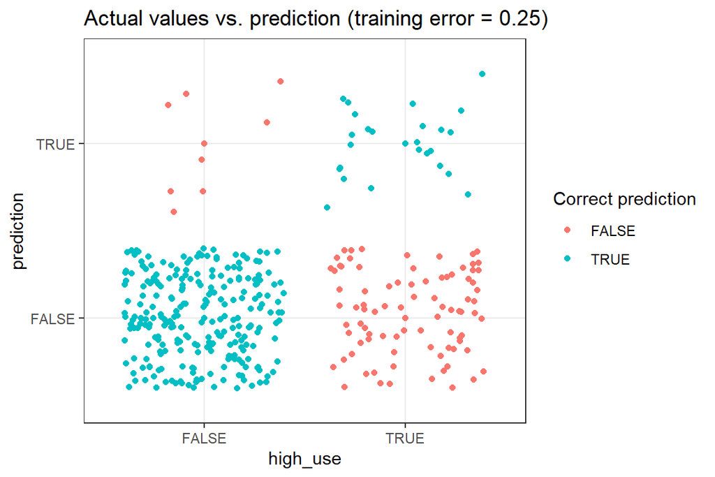

```r
v1 = c("word", "ok")

model_data %>%
  mutate(correct = high_use==prediction) %>%
  ggplot(aes(x = high_use, y=prediction, colour=correct))+
  geom_point()+
  geom_jitter()+
  labs(colour = "Correct prediction", title = "Actual values vs. prediction (training error = 0.25)")
```

Model has training error of 25%. It has tendency towards underprediction of alcohol use. It predicts around 3% of false positives (8/259), but large amount of false negatives, around 77% (86/111). I would not say that this model is actually useful.

```r
easy_prediction <- model_data %>%
  mutate(high_absences = absences>6) #lets compare how well over 6 absences predict high alcohol use

pred_table2 <- table(high_use = easy_prediction$high_use, prediction = easy_prediction$high_absences)

pred_table2
```

```
##         prediction
## high_use FALSE TRUE
##    FALSE   214   45
##    TRUE     71   40
```

If we take more simple approach and predict that those who have over 6 absences have high alcohol use we get more true positives and less true negative.

```r
(pred_table2[1,2] + pred_table2[2,1])/370
```

```
## [1] 0.3135135
```

Training error of the simpler model is 31% which is a little bit worse than the models training error (25%).

**7. cross-validation**

```r
loss_func <- function(class, prob) {
  n_wrong <- abs(class - prob) > 0.5
  mean(n_wrong)
}


# K-fold cross-validation
cv <- cv.glm(data = model_data, cost = loss_func, glmfit = fit2, K = nrow(model_data))

# average number of wrong predictions in the cross validation
cv$delta[1]
```

```
## [1] 0.2540541
```